# Shopee_Order_Brush

Kwok Cheong, Shu Min, Amy

4/10/2022

## Bring in library

```r
library(foreign)
library(ggplot2)
library(dplyr)
library(e1071)
library(corrplot)
library(randomForest)
library(naivebayes)
library(caret)
library(vcd)
library(gridExtra)
library(ggeffects)
library(smotefamily)
library(ROCR)
library(mlbench)
```

## Data Preprocess

```r
data <- read.csv("main_data_cleaned_v4.csv", header = TRUE)

# data preprocess
data$Orderbrush <- as.factor(data$Orderbrush)
data$Verified <- as.factor(data$Verified)
data$Shop.Followers.Cat <- as.factor(data$Shop.Followers.Cat)
data$Shop.Rating <- as.factor(data$Shop.Rating)

str(data)
```

```
## 'data.frame':    16969 obs. of  15 variables:
##  $ shopid             : int  122238789 193872265 178877065 120981896 69575583 45828982 84710867 71756544 640697 26974701 ...
##  $ Shop_name          : chr  "FILA Official Store" "Sasa Official Store" "Xiaomi Global Official Store" "Logitech Official Store" ...
##  $ Orderbrush         : Factor w/ 2 levels "No","Yes": 2 1 1 1 1 1 1 1 1 1 ...
##  $ Shop.Follower.Count: int  132751 116488 113943 105817 102473 97993 97136 93640 90425 86740 ...
##  $ Shop.Followers.Cat : Factor w/ 11 levels "<5000",">50000",..: 2 2 2 2 2 2 2 2 2 2 ...
##  $ Verified           : Factor w/ 2 levels "No","Yes": 1 1 1 1 1 1 1 1 1 1 ...
##  $ Shop.Rating.Value  : num  4.91 4.92 4.87 4.9 4.94 ...
##  $ Bad.Comments       : int  30 177 323 361 500 704 195 234 196 1004 ...
##  $ Normal.Comments    : int  6776 42792 34661 42999 166004 81110 31924 64501 90312 141063 ...
##  $ Good.Comments      : int  122 549 752 662 1675 2485 513 529 922 5555 ...
##  $ Total.Comments     : int  6928 43518 35736 44022 168179 84299 32632 65264 91430 147622 ...
##  $ Shop.Rating        : Factor w/ 4 levels "Above Average",..: 1 1 1 1 1 1 1 1 1 1 ...
##  $ Shop.Response.Rate : int  99 92 100 91 100 81 97 98 54 98 ...
##  $ Count.of.Order     : int  6 12 54 85 66 241 6 7 84 430 ...
##  $ Hour               : num  9.39 6.37 2.06 1.41 1.8 ...
```

```r
numData <- data[,3:15]

set.seed(122)
train_index <- createDataPartition(numData$Orderbrush, p=0.75, list= FALSE)
train <- numData[train_index, ] # 75% of the data
test <- numData[-train_index, ] # 25% of the data
```

## Data preprocess 2

```r
# for plotting purposes (corplot)
data_numeric <- subset(data, select = -c(Shop.Followers.Cat, Verified, Shop.Rating))
data_numeric <- data_numeric[,2:12]
data_numeric$Orderbrush <- as.numeric(data_numeric$Orderbrush) - 1

# if you only wan numeric and non categorical data, mainly using to do SMOTE
train_numeric <- subset(train, select = -c(Shop.Followers.Cat, Verified, Shop.Rating))
test_numeric <- subset(test, select = -c(Shop.Followers.Cat, Verified, Shop.Rating))
train_numeric$Orderbrush <- as.numeric(train_numeric$Orderbrush) - 1
test_numeric$Orderbrush <- as.numeric(test_numeric$Orderbrush) - 1

# 0 is non fraud, 1 is fraud
table(train_numeric$Orderbrush)
```

```
##
##     0     1
## 12438   290
```

```r
# perform smote on train data
train_smote <- SMOTE(X = train_numeric, target=train_numeric$Orderbrush, dup_size = 10)
train_smote_data <- train_smote$data
train_smote_data$Orderbrush <- as.factor(train_smote_data$Orderbrush)
levels(train_smote_data$Orderbrush) <- c("No", "Yes")
train_smote_data <- subset(train_smote_data, select = -c(class))
table(train_smote_data$Orderbrush)
```

```
##
##    No   Yes
## 12438  3190
```

## General Visualization Plot

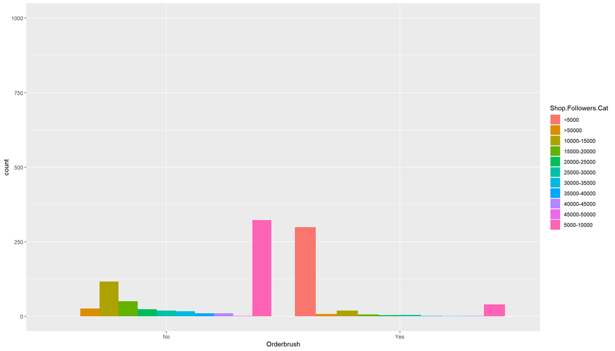

```r
ggplot(data, aes(x=Orderbrush, fill=Shop.Followers.Cat) ) + geom_bar(position="dodge", stat= "count") + ylim(0,1000)
```

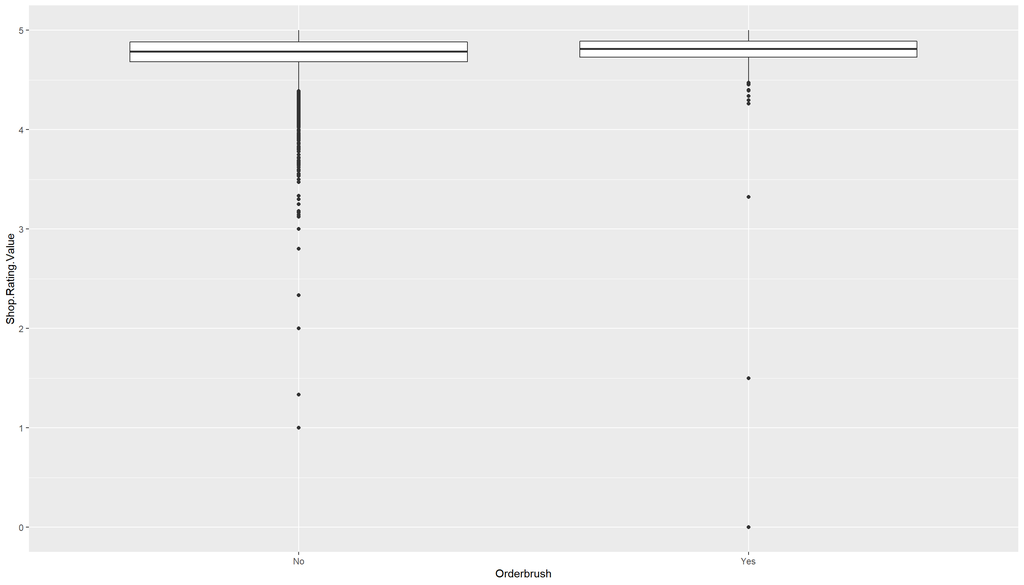

```r
ggplot(data, aes(x=Orderbrush, y=Shop.Rating.Value) ) + geom_boxplot(aes(fill=Shop.Rating.Value))
```

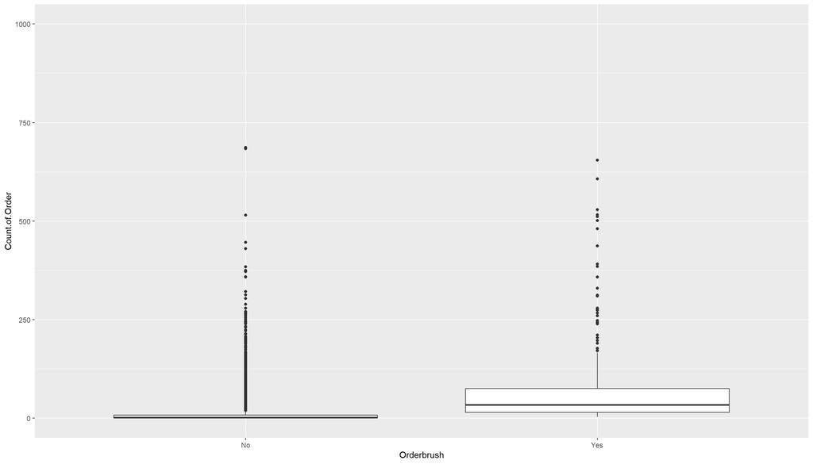

```r
ggplot(data, aes(x=Orderbrush, y=Count.of.Order) ) + geom_boxplot(aes(fill=Count.of.Order)) + ylim(0,1000)
```

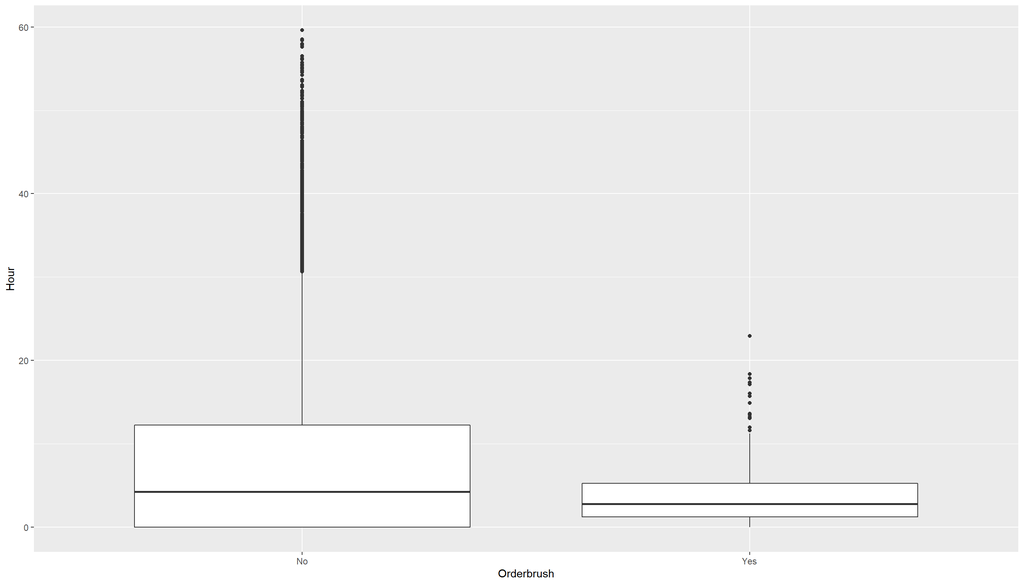

```r
ggplot(data, aes(x=Orderbrush, y=Hour) ) + geom_boxplot(aes(fill=Hour))
```

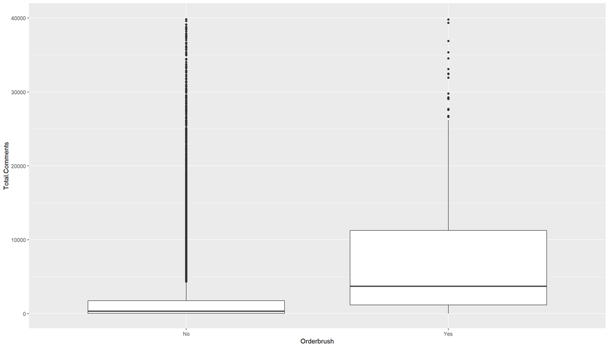

```r
ggplot(data, aes(x=Orderbrush, y=Total.Comments) ) + geom_boxplot(aes(fill=Total.Comments)) + ylim(0,40000)
```

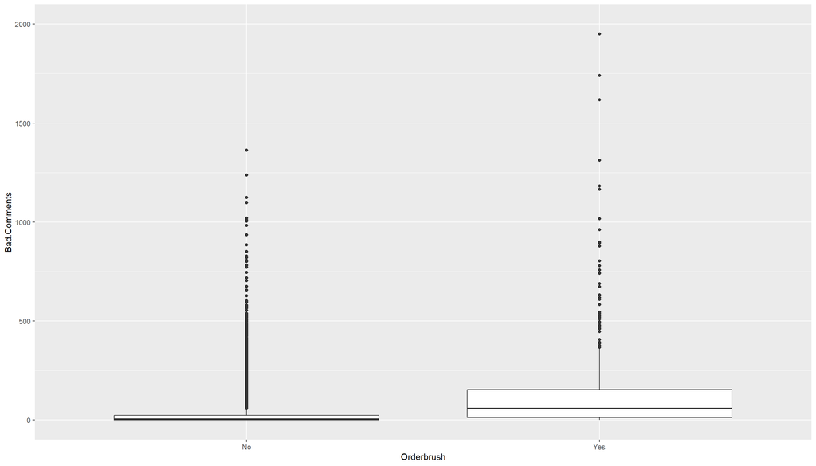

```r
ggplot(data, aes(x=Orderbrush, y=Bad.Comments) ) + geom_boxplot(aes(fill=Bad.Comments)) + ylim(0,2000)
```

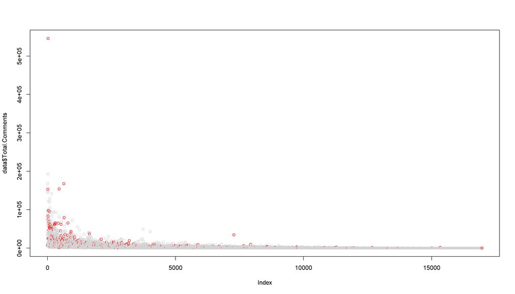

```r
plot(data$Total.Comments, col=c("lightgrey","red")[data$Orderbrush])
```

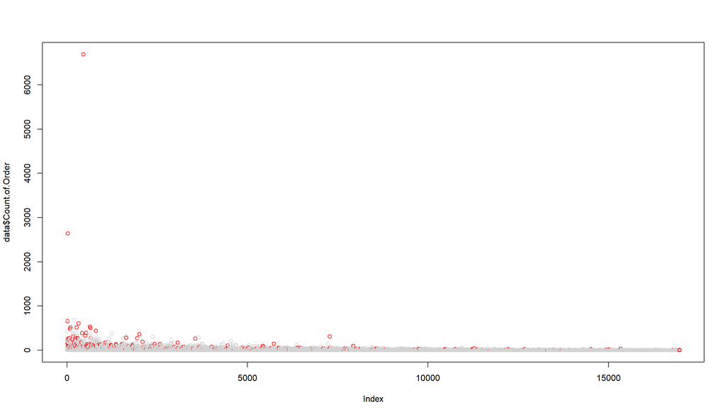

```r
plot(data$Count.of.Order, col=c("lightgrey","red")[data$Orderbrush])
```

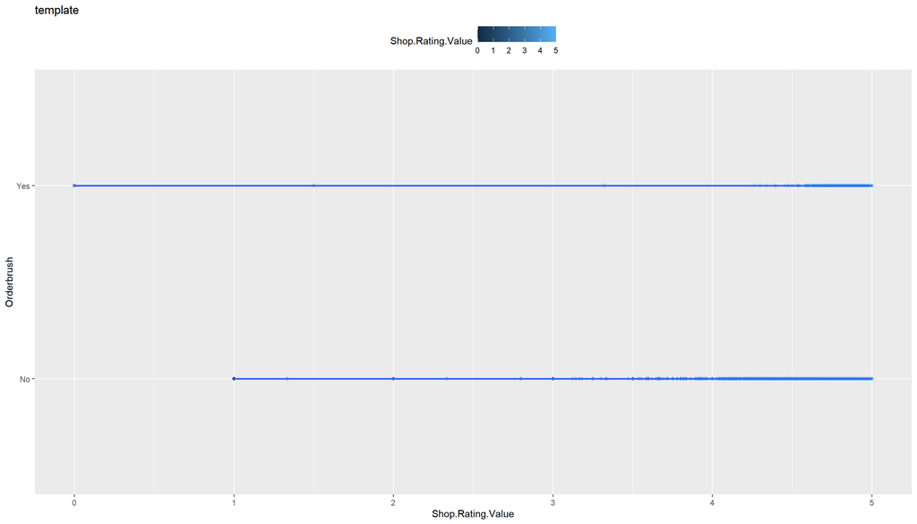

```r
ggplot(data, aes(Shop.Rating.Value, Orderbrush, colour=Shop.Rating.Value)) + geom_point(alpha=0.3) + theme(legend.position = "top") + labs(title="template") + geom_smooth(method="loess", se=FALSE)
```

## Correlation plot

```r
cor_data <- cor(x = data_numeric[sapply(data_numeric, is.numeric)], method="pearson")
round(cor_data,2)
```

```
##                     Orderbrush Shop.Follower.Count Shop.Rating.Value
## Orderbrush                1.00                0.13              0.01
## Shop.Follower.Count       0.13                1.00              0.09
## Shop.Rating.Value         0.01                0.09              1.00
## Bad.Comments              0.13                0.13              0.01
## Normal.Comments           0.19                0.62              0.09
## Good.Comments             0.18                0.46              0.04
## Total.Comments            0.20                0.62              0.09
## Shop.Response.Rate        0.04                0.10              0.07
## Count.of.Order            0.19                0.21              0.03
## Hour                     -0.06               -0.04              0.01
##                     Bad.Comments Normal.Comments Good.Comments Total.Comments
## Orderbrush                  0.13            0.19          0.18           0.20
## Shop.Follower.Count         0.13            0.62          0.46           0.62
## Shop.Rating.Value           0.01            0.09          0.04           0.09
## Bad.Comments                1.00            0.28          0.26           0.31
## Normal.Comments             0.28            1.00          0.71           1.00
## Good.Comments               0.26            0.71          1.00           0.72
## Total.Comments              0.31            1.00          0.72           1.00
## Shop.Response.Rate          0.05            0.13          0.13           0.13
## Count.of.Order              0.21            0.56          0.36           0.56
## Hour                       -0.03           -0.08         -0.09          -0.08
##                     Shop.Response.Rate Count.of.Order  Hour
## Orderbrush                        0.04           0.19 -0.06
## Shop.Follower.Count               0.10           0.21 -0.04
## Shop.Rating.Value                 0.07           0.03  0.01
## Bad.Comments                      0.05           0.21 -0.03
## Normal.Comments                   0.13           0.56 -0.08
## Good.Comments                     0.13           0.36 -0.09
## Total.Comments                    0.13           0.56 -0.08
## Shop.Response.Rate                1.00           0.04  0.00
## Count.of.Order                    0.04           1.00 -0.07
## Hour                              0.00          -0.07  1.00
```

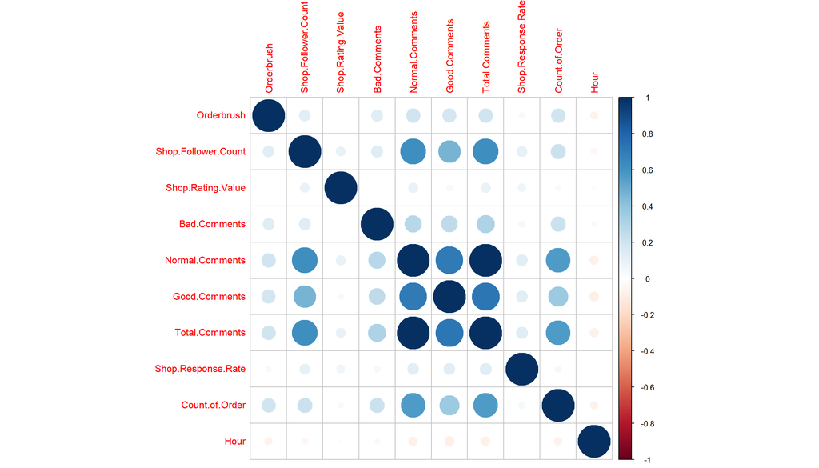

```r
correlation_plot <- corrplot(cor_data)
```

## Random Forest (Default - Train test)

```r
train_numeric$Orderbrush <- as.factor(train_numeric$Orderbrush)
test_numeric$Orderbrush <- as.factor(test_numeric$Orderbrush)
levels(train_numeric$Orderbrush) <- c("No", "Yes")
levels(test_numeric$Orderbrush) <- c("No", "Yes")

rf_model_default <- randomForest(formula = Orderbrush ~ ., data=train_numeric)
p_rf <- predict(rf_model_default, newdata=test_numeric)
confusionMatrix(as.factor(test_numeric$Orderbrush), p_rf ,mode = "prec_recall", positive="Yes")
```

```
## Confusion Matrix and Statistics
##
##           Reference
## Prediction   No  Yes
##        No  4142    3
##        Yes   92    4
##
##                Accuracy : 0.9776
##                  95% CI : (0.9727, 0.9818)
##     No Information Rate : 0.9983
##     P-Value [Acc > NIR] : 1
##
##                   Kappa : 0.0748
##
##  Mcnemar's Test P-Value : <2e-16
##
##               Precision : 0.0416667
##                  Recall : 0.5714286
##                      F1 : 0.0776699
##              Prevalence : 0.0016506
##          Detection Rate : 0.0009432
##    Detection Prevalence : 0.0226362
##       Balanced Accuracy : 0.7748499
##
##        'Positive' Class : Yes
##
```

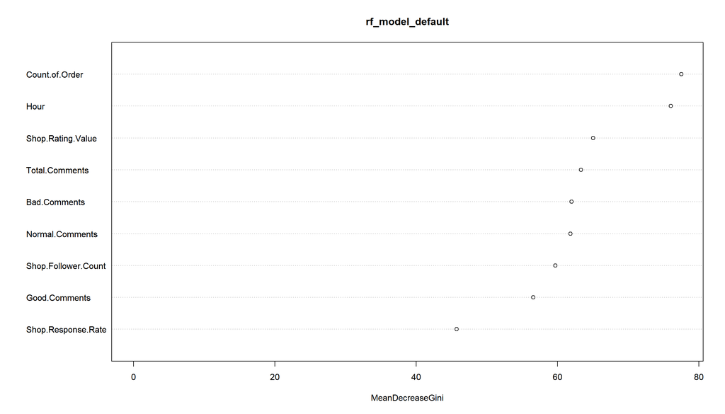

```r
varImpPlot(rf_model_default)
```

```r
varImp(rf_model_default)
```

```
##                      Overall
## Shop.Follower.Count 59.68872
## Shop.Rating.Value   65.05568
## Bad.Comments        61.96940
## Normal.Comments     61.81881
## Good.Comments       56.57318
## Total.Comments      63.33114
## Shop.Response.Rate  45.70774
## Count.of.Order      77.51015
## Hour                76.05145
```

## Random Forest (SMOTE)

```r
rf_model <- randomForest(formula = Orderbrush ~ ., data=train_smote_data )
p_rf <- predict(rf_model, newdata=test_numeric)
confusionMatrix(test_numeric$Orderbrush, p_rf)
```

```
## Confusion Matrix and Statistics
##
##           Reference
## Prediction   No  Yes
##        No  4027  118
##        Yes   77   19
##
##                Accuracy : 0.954
##                  95% CI : (0.9473, 0.9601)
##     No Information Rate : 0.9677
##     P-Value [Acc > NIR] : 0.999999
##
##                   Kappa : 0.1402
##
##  Mcnemar's Test P-Value : 0.004177
##
##             Sensitivity : 0.9812
##             Specificity : 0.1387
##          Pos Pred Value : 0.9715
##          Neg Pred Value : 0.1979
##              Prevalence : 0.9677
##          Detection Rate : 0.9495
##    Detection Prevalence : 0.9774
##       Balanced Accuracy : 0.5600
##
##        'Positive' Class : No
##
```

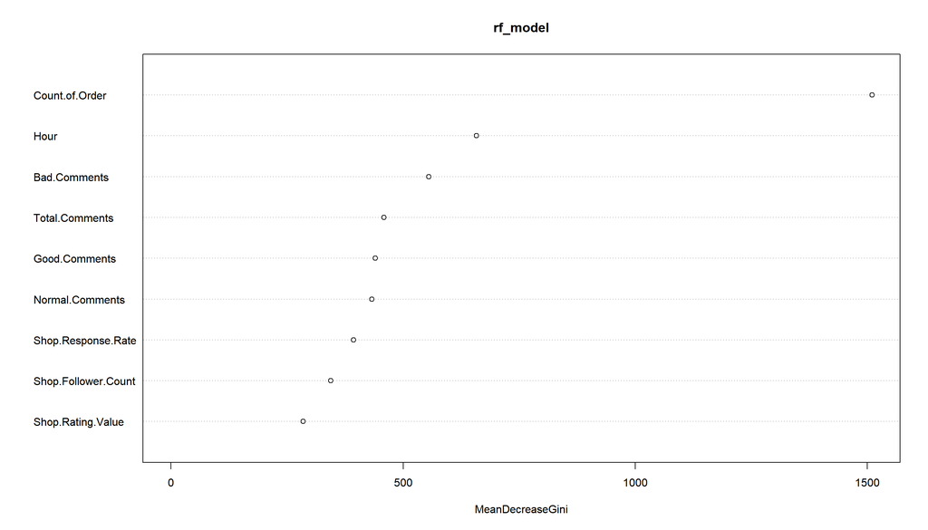

```r
varImpPlot(rf_model)
```

```r
varImp(rf_model)
```

```
##                       Overall
## Shop.Follower.Count  344.3633
## Shop.Rating.Value    284.3881
## Bad.Comments         555.2905
## Normal.Comments      432.3778
## Good.Comments        440.0902
## Total.Comments       458.4793
## Shop.Response.Rate   393.0763
## Count.of.Order      1509.8510
## Hour                 657.8308
```

## Random Forest (10 fold With undersample and preprocessing)

We use the caret package to run a repeated cross validation over 10 folds.

```r
# RF - CARET
ctrl <- trainControl(method = "repeatedcv",
                     number = 10,
                     repeats = 10,
                     verboseIter = FALSE,
                     sampling = "down")

random_f_model <- caret::train(Orderbrush ~ .,
                                   data = train,
                                   method = "rf",
                                   preProcess = c("scale", "center"),
                                   trControl = ctrl)

p_rf2 <- predict(random_f_model, newdata=test)
confusionMatrix(as.factor(test$Orderbrush), p_rf2, mode = "prec_recall", positive="Yes")
```

```
## Confusion Matrix and Statistics
##
##           Reference
## Prediction   No  Yes
##        No  3458  687
##        Yes   31   65
##
##                Accuracy : 0.8307
##                  95% CI : (0.8191, 0.8419)
##     No Information Rate : 0.8227
##     P-Value [Acc > NIR] : 0.08843
##
##                   Kappa : 0.1179
##
##  Mcnemar's Test P-Value : < 2e-16
##
##               Precision : 0.67708
##                  Recall : 0.08644
##                      F1 : 0.15330
##              Prevalence : 0.17732
##          Detection Rate : 0.01533
##    Detection Prevalence : 0.02264
##       Balanced Accuracy : 0.53878
##
##        'Positive' Class : Yes
##
```

```r
table(test$Orderbrush)
```

```
##
##   No  Yes
## 4145   96
```

```r
varImp(random_f_model, scale=FALSE)
```

```
## rf variable importance
##
##   only 20 most important variables shown (out of 23)
##
##                               Overall
## Count.of.Order                31.5416
## Hour                          21.2409
## Total.Comments                16.9935
## Bad.Comments                  16.8169
## Normal.Comments               16.5124
## Good.Comments                 14.8155
## Shop.Follower.Count           11.0803
## Shop.Response.Rate             5.8143
## Shop.Rating.Value              5.4366
## Shop.Followers.Cat5000-10000   1.4118
## VerifiedYes                    1.3272
## Shop.Followers.Cat10000-15000  0.4915
## Shop.Followers.Cat>50000       0.2561
## Shop.RatingNo Rating           0.2451
## Shop.Followers.Cat15000-20000  0.1961
## Shop.RatingBelow Average       0.1839
## Shop.Followers.Cat30000-35000  0.1754
## Shop.RatingAverage             0.1420
## Shop.Followers.Cat25000-30000  0.1189
## Shop.Followers.Cat20000-25000  0.1023
```

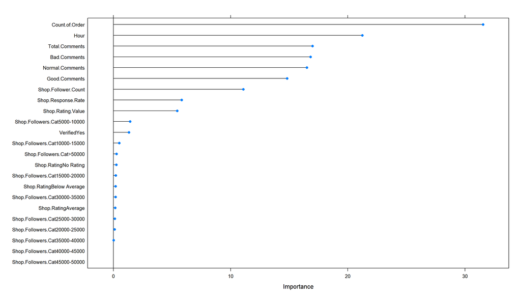

```r
plot(varImp(random_f_model, scale=FALSE))
```

## Random Forest (10 fold with undersample and scale center preprocessing)

```r
ctrl <- trainControl(method = "repeatedcv",
                     number = 10,
                     repeats = 10,
                     verboseIter = FALSE,
                     sampling="down")

random_f_model <- caret::train(Orderbrush ~ .,
                                   data = train,
                                   method = "rf",
                                   preProcess = c("scale", "center"),
                                   trControl = ctrl)

p_rf2 <- predict(random_f_model, newdata=test)
confusionMatrix(as.factor(test_numeric$Orderbrush), p_rf2, mode = "prec_recall", positive="Yes")
```

```
## Confusion Matrix and Statistics
##
##           Reference
## Prediction   No  Yes
##        No  3396  749
##        Yes   25   71
##
##                Accuracy : 0.8175
##                  95% CI : (0.8055, 0.829)
##     No Information Rate : 0.8066
##     P-Value [Acc > NIR] : 0.03771
##
##                   Kappa : 0.1193
##
##  Mcnemar's Test P-Value : < 2e-16
##
##               Precision : 0.73958
##                  Recall : 0.08659
##                      F1 : 0.15502
##              Prevalence : 0.19335
##          Detection Rate : 0.01674
##    Detection Prevalence : 0.02264
##       Balanced Accuracy : 0.53964
##
##        'Positive' Class : Yes
##
```

```r
table(test$Orderbrush)
```

```
##
##   No  Yes
## 4145   96
```

```r
varImp(random_f_model, scale=FALSE)
```

```
## rf variable importance
##
##   only 20 most important variables shown (out of 23)
##
##                                Overall
## Count.of.Order                31.23316
## Hour                          20.06312
## Bad.Comments                  15.20142
## Total.Comments                14.41069
## Normal.Comments               13.59912
## Good.Comments                 11.90082
## Shop.Follower.Count            9.74109
## Shop.Rating.Value              6.41818
## Shop.Response.Rate             4.46594
## Shop.Followers.Cat5000-10000   1.57020
## VerifiedYes                    1.12172
## Shop.Followers.Cat10000-15000  0.47106
## Shop.Followers.Cat>50000       0.31545
## Shop.Followers.Cat15000-20000  0.28741
## Shop.Followers.Cat25000-30000  0.24485
## Shop.RatingNo Rating           0.22220
## Shop.RatingBelow Average       0.16797
## Shop.Followers.Cat20000-25000  0.16045
## Shop.RatingAverage             0.10108
## Shop.Followers.Cat30000-35000  0.09025
```

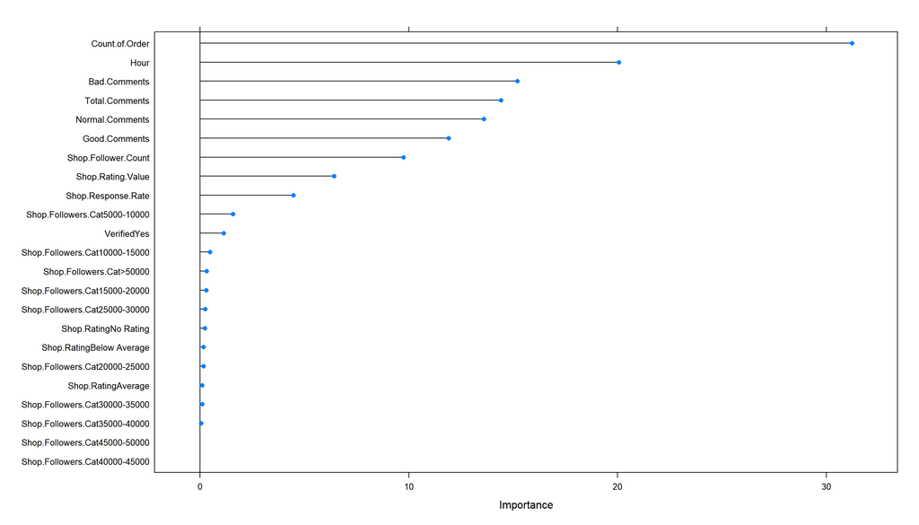

```r
plot(varImp(random_f_model, scale=FALSE))
```

## Random Forest (10 fold with undersample and normalization preprocessing)

```r
ctrl <- trainControl(method = "repeatedcv",
                     number = 10,
                     repeats = 10,
                     verboseIter = FALSE,
                     sampling="down")

random_f_model <- caret::train(Orderbrush ~ Shop.Follower.Count + Shop.Rating.Value + Bad.Comments + Normal.Comments + Good.Comments + Total.Comments + Shop.Response.Rate + Count.of.Order + Hour,
                                   data = train,
                                   method = "rf",
                                   preProcess = c("range"),
                                   trControl = ctrl)

p_rf2 <- predict(random_f_model, newdata=test)
confusionMatrix(as.factor(test$Orderbrush), p_rf2, mode = "prec_recall", positive="Yes")
```

```
## Confusion Matrix and Statistics
##
##           Reference
## Prediction   No  Yes
##        No  3375  770
##        Yes   19   77
##
##                Accuracy : 0.814
##                  95% CI : (0.8019, 0.8256)
##     No Information Rate : 0.8003
##     P-Value [Acc > NIR] : 0.01307
##
##                   Kappa : 0.1278
##
##  Mcnemar's Test P-Value : < 2e-16
##
##               Precision : 0.80208
##                  Recall : 0.09091
##                      F1 : 0.16331
##              Prevalence : 0.19972
##          Detection Rate : 0.01816
##    Detection Prevalence : 0.02264
##       Balanced Accuracy : 0.54266
##
##        'Positive' Class : Yes
##
```

```r
table(test$Orderbrush)
```

```
##
##   No  Yes
## 4145   96
```

```r
varImp(random_f_model, scale=FALSE)
```

```
## rf variable importance
##
##                     Overall
## Count.of.Order        68.96
## Hour                  47.06
## Total.Comments        35.10
## Normal.Comments       29.07
## Bad.Comments          29.01
## Good.Comments         26.72
## Shop.Follower.Count   22.31
## Shop.Rating.Value     17.40
## Shop.Response.Rate    13.75
```

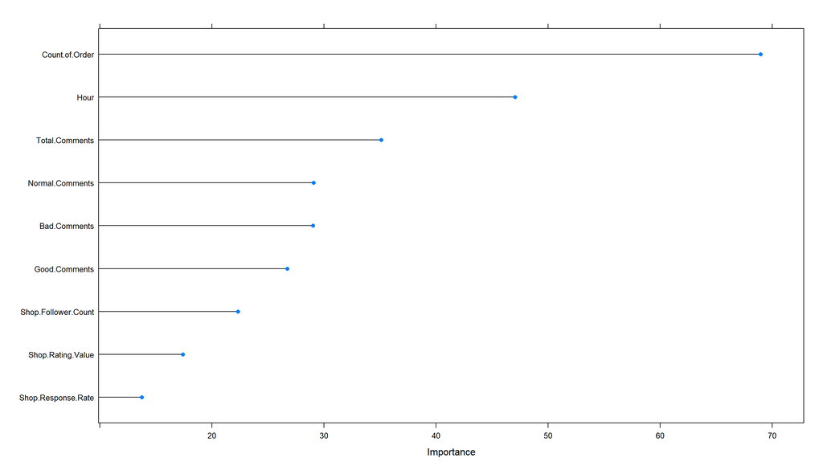

```r
plot(varImp(random_f_model, scale=FALSE))
```

## Naive Bayes

```r
model2 <- naive_bayes(Orderbrush~., data= train, laplace=1);
p <- predict(model2, test)

confusionMatrix(test$Orderbrush, p, mode = "prec_recall", positive="Yes")
```

```
## Confusion Matrix and Statistics
##
##           Reference
## Prediction   No  Yes
##        No  4010  135
##        Yes   65   31
##
##                Accuracy : 0.9528
##                  95% CI : (0.946, 0.959)
##     No Information Rate : 0.9609
##     P-Value [Acc > NIR] : 0.9961
##
##                   Kappa : 0.2141
##
##  Mcnemar's Test P-Value : 1.066e-06
##
##               Precision : 0.32292
##                  Recall : 0.18675
##                      F1 : 0.23664
##              Prevalence : 0.03914
##          Detection Rate : 0.00731
##    Detection Prevalence : 0.02264
##       Balanced Accuracy : 0.58540
##
##        'Positive' Class : Yes
##
```

```r
table(test$Orderbrush)
```

```
##
##   No  Yes
## 4145   96
```

```r
model3 <- naive_bayes(Orderbrush~., data= train_smote_data, laplace=1)
p_smote <- predict(model3, test)
confusionMatrix(test$Orderbrush, p_smote, mode = "prec_recall", positive="Yes")
```

```
## Confusion Matrix and Statistics
##
##           Reference
## Prediction   No  Yes
##        No  3981  164
##        Yes   63   33
##
##                Accuracy : 0.9465
##                  95% CI : (0.9393, 0.9531)
##     No Information Rate : 0.9535
##     P-Value [Acc > NIR] : 0.9855
##
##                   Kappa : 0.2009
##
##  Mcnemar's Test P-Value : 3.196e-11
##
##               Precision : 0.343750
##                  Recall : 0.167513
##                      F1 : 0.225256
##              Prevalence : 0.046451
##          Detection Rate : 0.007781
##    Detection Prevalence : 0.022636
##       Balanced Accuracy : 0.575967
##
##        'Positive' Class : Yes
##
```

## Logistic Regression method 1

Receiver Operator Characteristic (ROC) and Area Under the Curve (AUC) are typical performance measurements for a binary classifier.

ROC curve closer to the top-left corner indicate a better performance.

AUC between 0.5 to 1 mean the model with good predictive ability.

```r
train$Orderbrush <- as.factor(train$Orderbrush)
model3 <- glm(Orderbrush ~., family = binomial(link='logit'), data = train)
summary(model3)
```

```
##
## Call:
## glm(formula = Orderbrush ~ ., family = binomial(link = "logit"),
##     data = train)
##
## Deviance Residuals:
##     Min       1Q   Median       3Q      Max
## -4.9639  -0.2031  -0.1739  -0.1384   3.1371
##
## Coefficients: (1 not defined because of singularities)
##                                 Estimate Std. Error z value Pr(>|z|)
## (Intercept)                   -8.900e+00  2.131e+00  -4.176 2.97e-05 ***
## Shop.Follower.Count            1.439e-05  2.570e-05   0.560 0.575617
## Shop.Followers.Cat>50000      -1.034e-01  1.995e+00  -0.052 0.958660
## Shop.Followers.Cat10000-15000  1.651e-01  5.410e-01   0.305 0.760163
## Shop.Followers.Cat15000-20000  8.331e-01  7.518e-01   1.108 0.267767
## Shop.Followers.Cat20000-25000  1.639e+00  8.792e-01   1.864 0.062352 .
## Shop.Followers.Cat25000-30000  4.982e-01  1.089e+00   0.458 0.647225
## Shop.Followers.Cat30000-35000  9.163e-01  1.228e+00   0.746 0.455435
## Shop.Followers.Cat35000-40000  1.158e+00  1.427e+00   0.812 0.416997
## Shop.Followers.Cat40000-45000 -1.142e+01  3.076e+02  -0.037 0.970390
## Shop.Followers.Cat45000-50000 -1.492e+01  8.827e+02  -0.017 0.986515
## Shop.Followers.Cat5000-10000   1.125e+00  2.938e-01   3.828 0.000129 ***
## VerifiedYes                    3.472e-02  2.074e-01   0.167 0.867035
## Shop.Rating.Value              9.175e-01  4.435e-01   2.069 0.038564 *
## Bad.Comments                   8.460e-03  1.378e-03   6.141 8.21e-10 ***
## Normal.Comments               -2.072e-06  1.270e-05  -0.163 0.870411
## Good.Comments                 -3.716e-03  6.153e-04  -6.039 1.55e-09 ***
## Total.Comments                        NA         NA      NA       NA
## Shop.RatingAverage             3.465e-01  1.143e+00   0.303 0.761735
## Shop.RatingBelow Average       4.126e+00  1.722e+00   2.396 0.016559 *
## Shop.RatingNo Rating           2.349e+01  6.240e+02   0.038 0.969968
## Shop.Response.Rate             7.428e-03  3.027e-03   2.454 0.014140 *
## Count.of.Order                 1.851e-02  1.904e-03   9.720  < 2e-16 ***
## Hour                          -4.832e-02  1.087e-02  -4.447 8.71e-06 ***
## ---
## Signif. codes:  0 '***' 0.001 '**' 0.01 '*' 0.05 '.' 0.1 ' ' 1
##
## (Dispersion parameter for binomial family taken to be 1)
##
##     Null deviance: 2766.7  on 12727  degrees of freedom
## Residual deviance: 2286.9  on 12705  degrees of freedom
## AIC: 2332.9
##
## Number of Fisher Scoring iterations: 13
```

```r
fitted.results <- predict(model3, newdata = test, type='response')
fitted.results <- ifelse(fitted.results > 0.5,1,0)

misClasificError <- mean(fitted.results != test$Orderbrush)
print(paste('Accuracy',1-misClasificError))
```

```
## [1] "Accuracy 0"
```

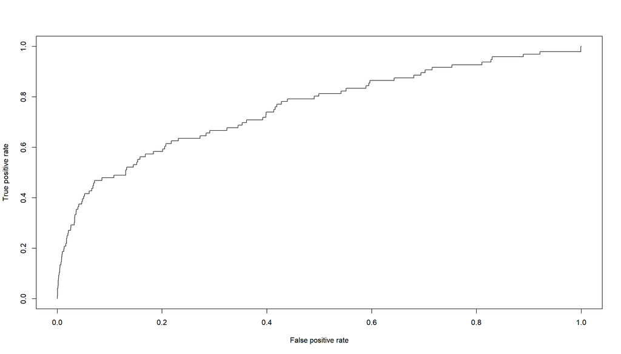

```r
p <- predict(model3, newdata = test, type="response")
pr <- prediction(p, test$Orderbrush)
prf <- performance(pr, measure = "tpr", x.measure = "fpr")
plot(prf)
```

```r
auc <- performance(pr, measure = "auc")
auc <- auc@y.values[[1]]
print(auc)
```

```
## [1] 0.7546818
```

## Logistic Regression method 2

We used glm method which specifies that we will fit a generalized linear model.

```r
ctrl <- trainControl(method = "repeatedcv",
                     number = 10,
                     repeats = 10,
                     verboseIter = FALSE,
                     sampling = "down")

metric <- "Accuracy"
tuneLength <- 10

train$Orderbrush <- as.factor(train$Orderbrush)

logistic_r_model <- caret::train(Orderbrush ~ .,
                               data = train,
                               method = "glm",
                               metric=metric,
                               preProcess = c("scale", "center"),
                               trControl = ctrl,
                               tuneLength = tuneLength)

print(logistic_r_model)
```

```
## Generalized Linear Model
##
## 12728 samples
##    12 predictor
##     2 classes: 'No', 'Yes'
##
## Pre-processing: scaled (23), centered (23)
## Resampling: Cross-Validated (10 fold, repeated 10 times)
## Summary of sample sizes: 11455, 11456, 11455, 11455, 11455, 11455, ...
## Addtional sampling using down-sampling prior to pre-processing
##
## Resampling results:
##
##   Accuracy  Kappa
##   0.866703  0.1546595
```

```r
p_lr <- predict(logistic_r_model, newdata=test)
confusionMatrix(as.factor(test$Orderbrush), p_lr, mode = "prec_recall", positive="Yes")
```

```
## Confusion Matrix and Statistics
##
##           Reference
## Prediction   No  Yes
##        No  3592  553
##        Yes   35   61
##
##                Accuracy : 0.8614
##                  95% CI : (0.8506, 0.8716)
##     No Information Rate : 0.8552
##     P-Value [Acc > NIR] : 0.1326
##
##                   Kappa : 0.1381
##
##  Mcnemar's Test P-Value : <2e-16
##
##               Precision : 0.63542
##                  Recall : 0.09935
##                      F1 : 0.17183
##              Prevalence : 0.14478
##          Detection Rate : 0.01438
##    Detection Prevalence : 0.02264
##       Balanced Accuracy : 0.54485
##
##        'Positive' Class : Yes
##
```

```r
table(test$Orderbrush)
```

```
##
##   No  Yes
## 4145   96
```

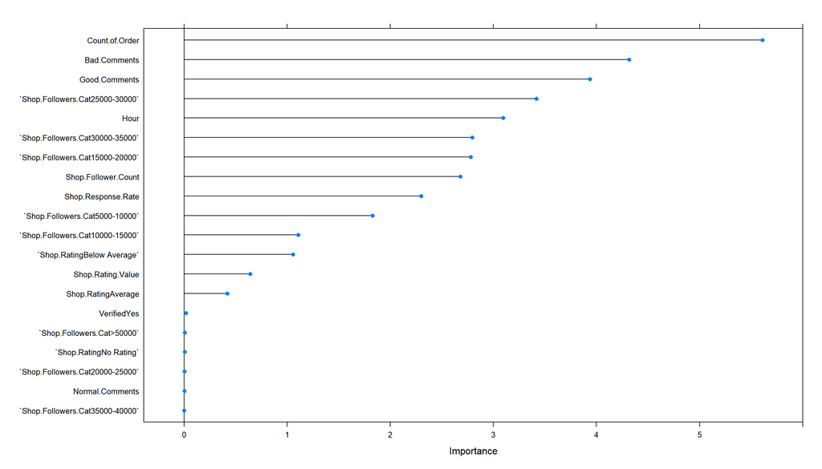

```r
plot(varImp(logistic_r_model, scale=FALSE))
```

## Support Vector Machines (SVM) Linear Classifier

We used SVM linear classifier, the variables are normalized to make their scale comparable.

Tuning parameter C (Cost) is to determine the possible misclassifications. The higher the value of C, the less likely it is that the SVM algorithm will misclassify a point.

We build using the default C = 1. The accuracy of this model is 0.8880263.

```r
ctrl <- trainControl(method = "repeatedcv",
                     number = 10,
                     repeats = 10,
                     verboseIter = FALSE,
                     sampling = "down")

train$Orderbrush <- as.factor(train$Orderbrush)

svm_model <- caret::train(Orderbrush ~ .,
                                 data = train,
                                 method = "svmLinear",
                                 preProcess = c("scale", "center"),
                                 trControl = ctrl)

print(svm_model)
```

```
## Support Vector Machines with Linear Kernel
##
## 12728 samples
##    12 predictor
##     2 classes: 'No', 'Yes'
##
## Pre-processing: scaled (23), centered (23)
## Resampling: Cross-Validated (10 fold, repeated 10 times)
## Summary of sample sizes: 11455, 11455, 11456, 11455, 11456, 11455, ...
## Addtional sampling using down-sampling prior to pre-processing
##
## Resampling results:
##
##   Accuracy   Kappa
##   0.8880263  0.1612465
##
## Tuning parameter 'C' was held constant at a value of 1
```

```r
p_svm <- predict(svm_model, newdata=test)
confusionMatrix(as.factor(test$Orderbrush), p_svm, mode = "prec_recall", positive="Yes")
```

```
## Confusion Matrix and Statistics
##
##           Reference
## Prediction   No  Yes
##        No  3770  375
##        Yes   48   48
##
##                Accuracy : 0.9003
##                  95% CI : (0.8908, 0.9091)
##     No Information Rate : 0.9003
##     P-Value [Acc > NIR] : 0.5129
##
##                   Kappa : 0.1537
##
##  Mcnemar's Test P-Value : <2e-16
##
##               Precision : 0.50000
##                  Recall : 0.11348
##                      F1 : 0.18497
##              Prevalence : 0.09974
##          Detection Rate : 0.01132
##    Detection Prevalence : 0.02264
##       Balanced Accuracy : 0.55045
##
##        'Positive' Class : Yes
##
```

```r
table(test$Orderbrush)
```

```
##
##   No  Yes
## 4145   96
```

```r
plot(varImp(svm_model, scale=FALSE))
```

[output not shown]

```r
# Make predictions on the test data
predicted.classes <- svm_model %>% predict(test)
# Compute model accuracy rate
accuracy_rate <- mean(predicted.classes == test$Orderbrush)
print(accuracy_rate)
```

```
## [1] 0.9002594
```

## Support Vector Machines (SVM) Linear with Choice of Cost

We compute SVM for a grid values of C and choose automatically the final model for predictions.

```r
svm_model2 <- caret::train(Orderbrush ~ .,
                          data = train,
                          method = "svmLinear",
                          preProcess = c("scale", "center"),
                          trControl = ctrl,
                          tuneGrid = expand.grid(C = seq(0, 2, length = 20)))

print(svm_model2)
```

```
## Support Vector Machines with Linear Kernel
##
## 12728 samples
##    12 predictor
##     2 classes: 'No', 'Yes'
##
## Pre-processing: scaled (23), centered (23)
## Resampling: Cross-Validated (10 fold, repeated 10 times)
## Summary of sample sizes: 11455, 11456, 11455, 11455, 11455, 11455, ...
## Addtional sampling using down-sampling prior to pre-processing
##
## Resampling results across tuning parameters:
##
##   C          Accuracy   Kappa
##   0.0000000        NaN        NaN
##   0.1052632  0.8841147  0.1270212
##   0.2105263  0.8817566  0.1315338
##   0.3157895  0.8844363  0.1401343
##   0.4210526  0.8851272  0.1473499
##   0.5263158  0.8842862  0.1505301
##   0.6315789  0.8849304  0.1533213
##   0.7368421  0.8863138  0.1569732
##   0.8421053  0.8863452  0.1551454
##   0.9473684  0.8868006  0.1595687
##   1.0526316  0.8857794  0.1585274
##   1.1578947  0.8899742  0.1627526
##   1.2631579  0.8865340  0.1601041
##   1.3684211  0.8872640  0.1612881
##   1.4736842  0.8894091  0.1630628
##   1.5789474  0.8855909  0.1627051
##   1.6842105  0.8871073  0.1626632
##   1.7894737  0.8859841  0.1633277
##   1.8947368  0.8854652  0.1620962
##   2.0000000  0.8853312  0.1613925
##
## Accuracy was used to select the optimal model using the largest value.
## The final value used for the model was C = 1.157895.
```

```r
p_svm2 <- predict(svm_model2, newdata=test)
confusionMatrix(as.factor(test$Orderbrush), p_svm2, mode = "prec_recall", positive="Yes")
```

```
## Confusion Matrix and Statistics
##
##           Reference
## Prediction   No  Yes
##        No  3760  385
##        Yes   48   48
##
##                Accuracy : 0.8979
##                  95% CI : (0.8884, 0.9069)
##     No Information Rate : 0.8979
##     P-Value [Acc > NIR] : 0.5128
##
##                   Kappa : 0.15
##
##  Mcnemar's Test P-Value : <2e-16
##
##               Precision : 0.50000
##                  Recall : 0.11085
##                      F1 : 0.18147
##              Prevalence : 0.10210
##          Detection Rate : 0.01132
##    Detection Prevalence : 0.02264
##       Balanced Accuracy : 0.54912
##
##        'Positive' Class : Yes
##
```

```r
table(test$Orderbrush)
```

```
##
##   No  Yes
## 4145   96
```

```r
plot(varImp(svm_model2, scale=FALSE))
```

[output not shown]

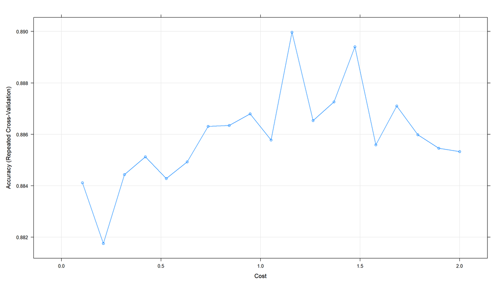

```r
# Plot model accuracy vs different values of Cost
plot(svm_model2)
```

```r
# Make predictions on the test data
predicted.classes2 <- svm_model2 %>% predict(test)
# Compute model accuracy rate
accuracy_rate2 <- mean(predicted.classes2 == test$Orderbrush)
print(accuracy_rate2)
```

```
## [1] 0.8979014
```

## Support Vector Machines (SVM) Non-Linear Kernel (Radial)

We used radial kernel function to build non-linear SVM classifier.

```r
ctrl <- trainControl(method = "repeatedcv",
                     number = 10,
                     repeats = 10,
                     verboseIter = FALSE,
                     sampling = "down")

svm_model3 <- caret::train(Orderbrush ~ .,
                          data = train,
                          method = "svmRadial",
                          preProcess = c("scale", "center"),
                          trControl = ctrl,
                          tuneLength = 10)

print(svm_model3)
```

```
## Support Vector Machines with Radial Basis Function Kernel
##
## 12728 samples
##    12 predictor
##     2 classes: 'No', 'Yes'
##
## Pre-processing: scaled (23), centered (23)
## Resampling: Cross-Validated (10 fold, repeated 10 times)
## Summary of sample sizes: 11456, 11455, 11455, 11455, 11455, 11455, ...
## Addtional sampling using down-sampling prior to pre-processing
##
## Resampling results across tuning parameters:
##
##   C       Accuracy   Kappa
##     0.25  0.7045085  0.06734461
##     0.50  0.7189963  0.07705339
##     1.00  0.7160978  0.07849390
##     2.00  0.7143934  0.07887062
##     4.00  0.7141735  0.07700350
##     8.00  0.7233657  0.08040447
##    16.00  0.7273020  0.07871627
##    32.00  0.7311591  0.08039135
##    64.00  0.7413034  0.08086801
##   128.00  0.7406976  0.07812550
##
## Tuning parameter 'sigma' was held constant at a value of 0.4067107
## Accuracy was used to select the optimal model using the largest value.
## The final values used for the model were sigma = 0.4067107 and C = 64.
```

```r
p_svm3 <- predict(svm_model3, newdata=test)
confusionMatrix(as.factor(test$Orderbrush), p_svm3, mode = "prec_recall", positive="Yes")
```

```
## Confusion Matrix and Statistics
##
##           Reference
## Prediction   No  Yes
##        No  3258  887
##        Yes   26   70
##
##                Accuracy : 0.7847
##                  95% CI : (0.772, 0.797)
##     No Information Rate : 0.7743
##     P-Value [Acc > NIR] : 0.05443
##
##                   Kappa : 0.0957
##
##  Mcnemar's Test P-Value : < 2e-16
##
##               Precision : 0.72917
##                  Recall : 0.07315
##                      F1 : 0.13295
##              Prevalence : 0.22565
##          Detection Rate : 0.01651
##    Detection Prevalence : 0.02264
##       Balanced Accuracy : 0.53261
##
##        'Positive' Class : Yes
##
```

```r
table(test$Orderbrush)
```

```
##
##   No  Yes
## 4145   96
```

```r
plot(varImp(svm_model3, scale=FALSE))
```

[output not shown]

```r
# Make predictions on the test data
predicted.classes3 <- svm_model3 %>% predict(test)
# Compute model accuracy rate
accuracy_rate3 <- mean(predicted.classes3 == test$Orderbrush)
print(accuracy_rate3)
```

```
## [1] 0.7847206
```

## Support Vector Machines (SVM) Non-Linear Kernel (Polynomial)

We used polynomial kernel function to build non-linear SVM classifier.

```r
ctrl <- trainControl(method = "repeatedcv",
                     number = 10,
                     repeats = 10,
                     verboseIter = FALSE,
                     sampling = "down")

svm_model4 <- caret::train(Orderbrush ~ .,
                          data = train,
                          method = "svmPoly",
                          preProcess = c("scale", "center"),
                          trControl = ctrl,
                          tuneLength = 4)

print(svm_model4)
```

```
## Support Vector Machines with Polynomial Kernel
##
## 12728 samples
##    12 predictor
##     2 classes: 'No', 'Yes'
##
## Pre-processing: scaled (23), centered (23)
## Resampling: Cross-Validated (10 fold, repeated 10 times)
## Summary of sample sizes: 11455, 11455, 11455, 11455, 11456, 11455, ...
## Addtional sampling using down-sampling prior to pre-processing
##
## Resampling results across tuning parameters:
##
##   degree  scale  C     Accuracy   Kappa
##   1       0.001  0.25  0.9762098  0.02982995
```

[output cut: 50 more lines]

```r
p_svm4 <- predict(svm_model4, newdata=test)
confusionMatrix(as.factor(test$Orderbrush), p_svm4, mode = "prec_recall", positive="Yes")
```

```
## Confusion Matrix and Statistics
##
##           Reference
## Prediction   No  Yes
##        No  4140    5
##        Yes   92    4
##
##                Accuracy : 0.9771
##                  95% CI : (0.9722, 0.9814)
##     No Information Rate : 0.9979
##     P-Value [Acc > NIR] : 1
##
##                   Kappa : 0.0726
##
##  Mcnemar's Test P-Value : <2e-16
##
##               Precision : 0.0416667
##                  Recall : 0.4444444
##                      F1 : 0.0761905
##              Prevalence : 0.0021221
##          Detection Rate : 0.0009432
##    Detection Prevalence : 0.0226362
##       Balanced Accuracy : 0.7113527
##
##        'Positive' Class : Yes
##
```

```r
table(test$Orderbrush)
```

```
##
##   No  Yes
## 4145   96
```

```r
plot(varImp(svm_model4, scale=FALSE))
```

[output not shown]

```r
# Make predictions on the test data
predicted.classes4 <- svm_model4 %>% predict(test)
# Compute model accuracy rate
accuracy_rate4 <- mean(predicted.classes4 == test$Orderbrush)
print(accuracy_rate4)
```

```
## [1] 0.977128
```

## Support Vector Machines (SVM) Comparison

Compare all 4 methods, linear and non-linear.

```r
df <- tibble(Model = c('SVM Linear','SVM Linear w/ choice of cost','SVM Radial','SVM Poly'), Accuracy = c(accuracy_rate, accuracy_rate2, accuracy_rate3, accuracy_rate4))
df %>% arrange(Accuracy)
```

```
## # A tibble: 4 x 2
##   Model                        Accuracy
##   <chr>                           <dbl>
## 1 SVM Radial                      0.785
## 2 SVM Linear w/ choice of cost    0.898
## 3 SVM Linear                      0.900
## 4 SVM Poly                        0.977
```